# DATA2002 lab8

Jing Yang 480110301

10/21/2020

# Questions

## Critical flicker frequency

```r
library(tidyverse)
flicker = read_tsv("https://raw.githubusercontent.com/DATA2002/data/master/flicker.txt")
glimpse(flicker)
```

```
## Rows: 19
## Columns: 2
## $ Colour  <chr> "Brown", "Brown", "Brown", "Brown", "Brown", "Brown", "Brown…
## $ Flicker <dbl> 26.8, 27.9, 23.7, 25.0, 26.3, 24.8, 25.7, 24.5, 26.4, 24.2, …
```

```r
flicker
```

```
## # A tibble: 19 x 2
##    Colour Flicker
##    <chr>    <dbl>
##  1 Brown     26.8
##  2 Brown     27.9
##  3 Brown     23.7
##  4 Brown     25
##  5 Brown     26.3
##  6 Brown     24.8
##  7 Brown     25.7
##  8 Brown     24.5
##  9 Green     26.4
## 10 Green     24.2
## 11 Green     28
## 12 Green     26.9
## 13 Green     29.1
## 14 Blue      25.7
## 15 Blue      27.2
## 16 Blue      29.9
## 17 Blue      28.5
## 18 Blue      29.4
## 19 Blue      28.3
```

1. Generate side by side boxplots as well as normal QQ plots for the flicker data. Do your plots support the assumptions required for an ANOVA test to be valid? Explain.

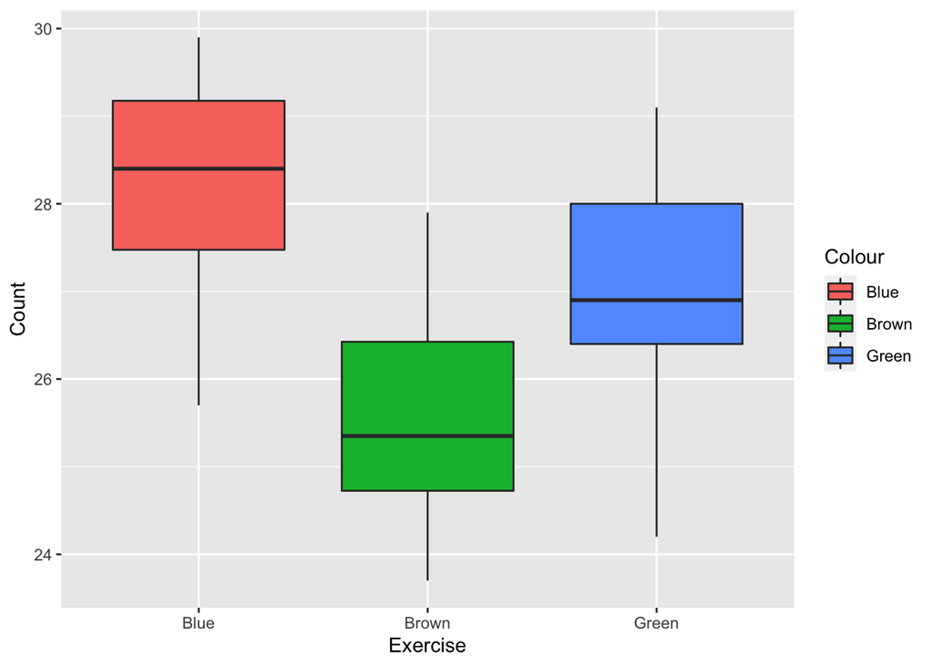

```r
ggplot(flicker, aes(x= Colour,y=Flicker,fill=Colour))+
  geom_boxplot(aes(x= Colour,y=Flicker), outlier.alpha = 0.5)+labs(y = "Count", x = "Exercise")
```

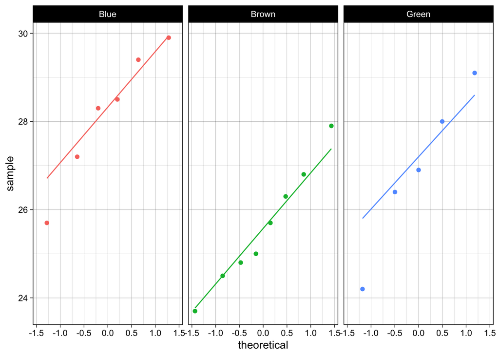

```r
ggplot(flicker, aes(sample=Flicker,color=Colour)) + geom_qq() + geom_qq_line()+facet_wrap(~ Colour)+theme_classic()+theme_linedraw() + theme(legend.position = "none")
```

2. Use the aov() function to perform an ANOVA test for the equality of means flicker level across each of the three eye colours.

```r
(aov = summary(aov(Flicker ~ Colour, data = flicker)))
```

```
##             Df Sum Sq Mean Sq F value Pr(>F)
## Colour       2  23.00  11.499   4.802 0.0232 *
## Residuals   16  38.31   2.394
## ---
## Signif. codes:  0 '***' 0.001 '**' 0.01 '*' 0.05 '.' 0.1 ' ' 1
```

```r
n = length(flicker$Flicker)
g = length(unique(flicker$Colour))
df1 = aov[[1]][["Df"]][1]
df2 = aov[[1]][["Df"]][2]
ms1 = aov[[1]][["Mean Sq"]][1]
ms2 = aov[[1]][["Mean Sq"]][2]
t0 = ms1/ms2
pval = aov[[1]][["Pr(>F)"]][1]
```

3. Using the output, write out the hypothesis test in full. Be sure to state the null and alternative hypothesis, assumptions, test statistic (with distribution), observed test statistic, p-value and an appropriate conclusion.